# Pertemuan 5

Naswa Nabila Zahrani

2023-10-01

```r
library(ggplot2)
library(tsibble)
library(tseries)
library(MASS)
```

## Stasioner dalam Rataan dan Ragam

Pada dasarnya, pembangkitan data ARIMA akan menghasilkan data yang stasioner dalam rataan dan ragam karena akan mengikuti fungsi *default*-nya yang mengikuti pembangkitan bilangan acak normal dengan `mean=0` dan `ragam=1` .

```r
library("rio")
datal <- import("https://raw.githubusercontent.com/naswa/MPDW/main/Pertemuan%205/Tesla%20Arima.csv")
stas <- ts(datal$Close)
stas
```

```
## Time Series:
## Start = 1
## End = 150
## Frequency = 1
##   [1] 246.7900 258.3333 234.5167 238.2800 238.8867 241.8667 239.7067 232.2300
##   [9] 215.7367 220.8900 233.0000 213.1000 216.7600 237.0367 236.0867 235.0700
##  [17] 245.7067 244.9200 232.6633 228.4900 224.4733 227.2633 233.0667 231.7333
##  [25] 244.5433 250.7633 234.3433 233.0700 237.0400 238.3133 240.0667 240.5467
##  [33] 245.5300 247.5000 271.7067 272.2433 268.4333 258.8600 274.8200 280.9000
##  [41] 297.1500 297.2767 300.5867 307.3967 308.6333 288.1700 290.4233 283.3333
##  [49] 294.3567 286.6300 300.0300 309.3200 306.5633 303.9967 302.8700 296.6667
##  [57] 289.9133 296.4533 297.0967 296.0700 288.0900 284.8200 277.7000 275.6100
##  [65] 277.1600 270.2100 274.4200 283.7000 289.2600 299.6800 304.4200 292.1300
##  [73] 302.6100 303.7500 303.3500 309.0700 308.7300 300.8000 288.5900 275.3300
##  [81] 276.0100 282.9400 287.8100 268.2100 265.2500 242.4000 249.4400 240.8100
##  [89] 238.1300 223.0700 222.9600 216.5000 217.2400 221.7200 204.9900 219.3500
##  [97] 220.1900 222.0400 207.2800 214.4400 211.2500 222.4200 224.6400 225.0900
## [105] 228.5200 227.5400 227.8200 214.9800 215.3100 207.4700 197.0800 191.3000
## [113] 177.5900 190.7200 195.9700 190.9500 194.4200 186.9200 183.1700 180.1900
## [121] 167.8700 169.9100 183.2000 182.8600 182.9200 180.8300 194.7000 194.7000
## [129] 194.8600 182.4500 179.8200 174.0400 173.4400 179.0500 167.8200 160.9500
## [137] 156.8000 157.6700 150.2300 149.8700 137.8000 137.5700 125.3500 123.1500
## [145] 109.1000 112.7100 121.8200 123.1800 108.1000 113.6400
```

### Plot *Time Series*

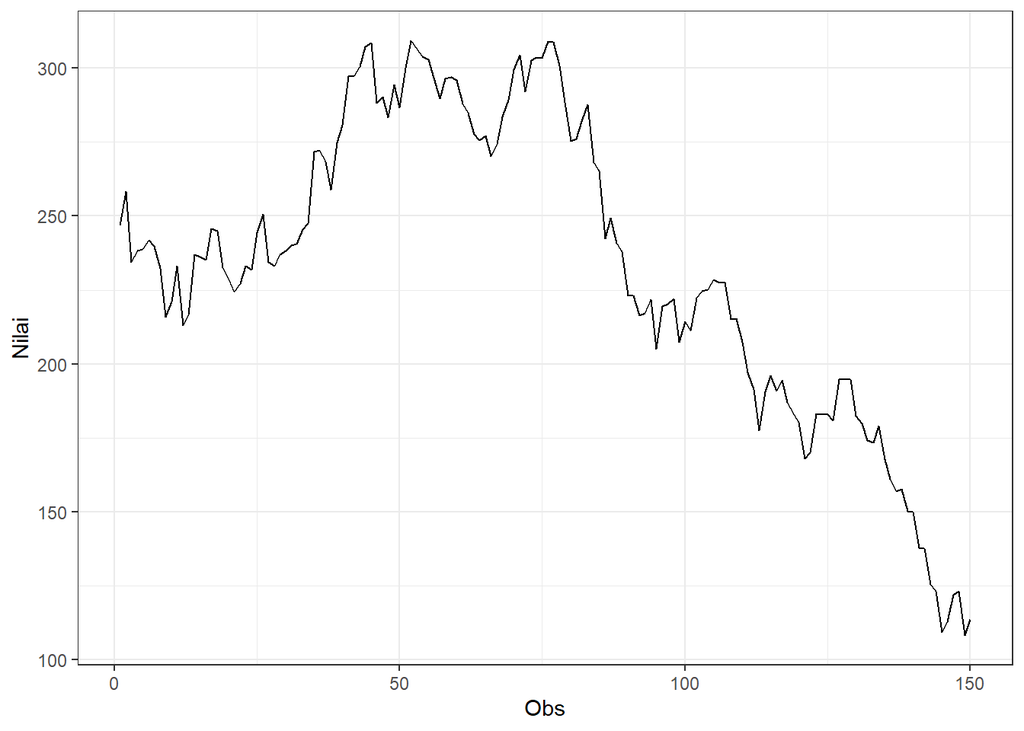

```r
plot_stas <- stas |> as_tsibble() |>
  ggplot(aes(x = index, y = value)) + geom_line() + theme_bw() +
  xlab("Obs") + ylab("Nilai")
plot_stas
```

```r
mean(stas)
```

```
## [1] 232.9213
```

Plot deret waktu di atas menunjukkan bahwa data tidak stasioner dalam rataan dan tidak stasioner dalam ragam.

### Plot ACF

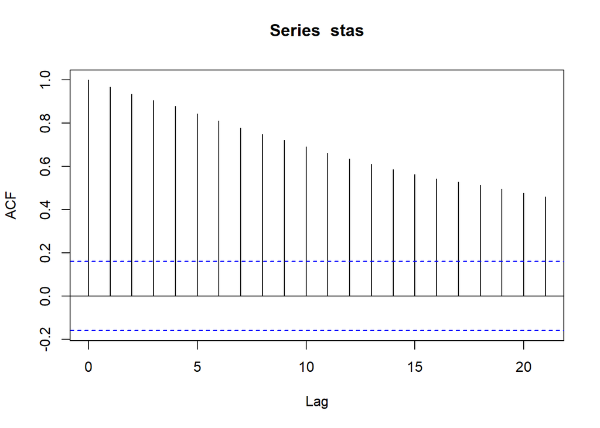

```r
acf(stas)
```

Berdasarkan plot ACF, terlihat bahwa plot ACF pada data tersebut cenderung *tails off* dan data belum stasioner ketikan grafik terlihat meluruh secara melambat menuju 0.

### Uji ADF

```r
tseries::adf.test(stas)
```

```
##
##  Augmented Dickey-Fuller Test
##
## data:  stas
## Dickey-Fuller = -1.0366, Lag order = 5, p-value = 0.9295
## alternative hypothesis: stationary
```

$H_0$ : Data tidak stasioner dalam rataan

$H_1$ : Data stasioner dalam rataan

Berdasarkan uji ADF tersebut, didapat *p-value* sebesar 0.9295 yang lebih besar dari taraf nyata 5% sehinggatak tolak $H_0$ dan menandakan bahwa data tidak stasioner dalam rataan. Hal ini sesuai dengan hasil eksplorasi menggunakan plot time series dan plot ACF.

### Plot Box-Cox

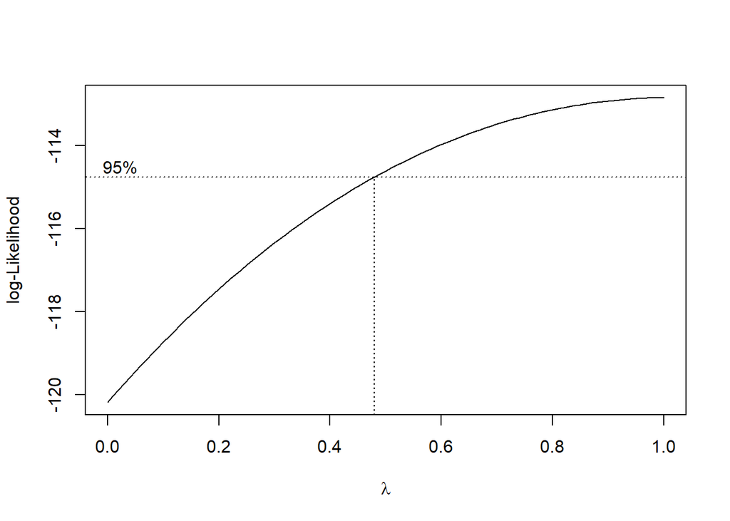

```r
index <- seq(1:150)
bc = boxcox(stas~index, lambda = seq(0,1,by=0.01))
```

```r
#Nilai Rounded Lambda
lambda <- bc$x[which.max(bc$y)]
lambda
```

```
## [1] 1
```

```r
#SK
bc$x[bc$y > max(bc$y) - 1/2 * qchisq(.95,1)]
```

```
##  [1] 0.48 0.49 0.50 0.51 0.52 0.53 0.54 0.55 0.56 0.57 0.58 0.59 0.60 0.61 0.62
## [16] 0.63 0.64 0.65 0.66 0.67 0.68 0.69 0.70 0.71 0.72 0.73 0.74 0.75 0.76 0.77
## [31] 0.78 0.79 0.80 0.81 0.82 0.83 0.84 0.85 0.86 0.87 0.88 0.89 0.90 0.91 0.92
## [46] 0.93 0.94 0.95 0.96 0.97 0.98 0.99 1.00
```

Gambar di atas menunjukkan nilai *rounded value* ($\lambda$) optimum sebesar **1** dan pada selang kepercayaan 95% nilai memiliki batas bawah **0.48** dan batas atas **1**. Selang tersebut memuat nilai satu sehingga dapat dikatakan bahwa data stasioner dalam ragam.

### Partisi Data

#### Bagian 1

```r
dt_stas1 <- stas[1:127] |> ts()
mean(dt_stas1)
```

```
## [1] 248.0636
```

```r
var(dt_stas1)
```

```
## [1] 1528.882
```

#### Plot Time Series

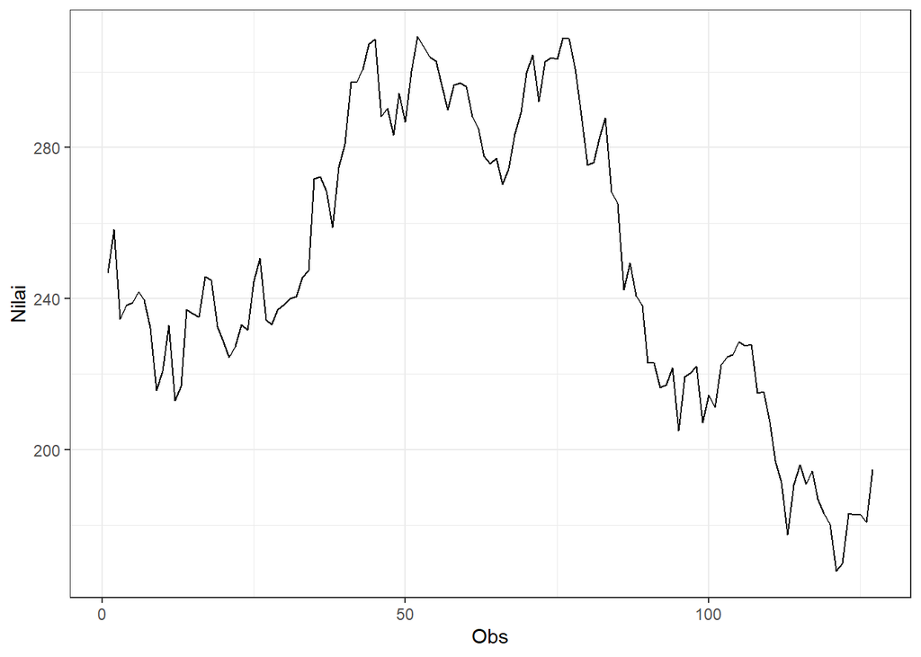

```r
dt_stas1 |> as_tsibble() |>
  ggplot(aes(x = index, y = value)) +
  geom_line() + theme_bw() +
  xlab("Obs") + ylab("Nilai")
```

Plot deret waktu di atas menunjukkan bahwa data tidak stasioner dalam rataan, ditandai dengan data yang tidak menyebar di sekitar nilai tengahnya dan tidak stasioner dalam ragam, ditandai dengan lebar pita yang cenderung tidak sama.

#### Plot ACF

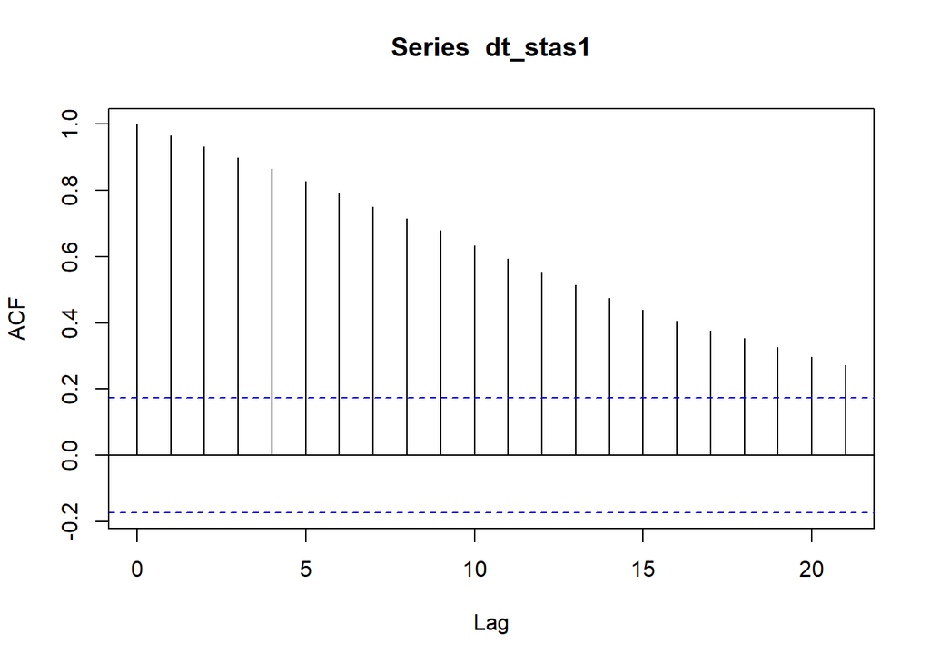

```r
acf(dt_stas1)
```

Berdasarkan plot ACF, terlihat bahwa plot ACF pada data tersebut cenderung *tails off* dan data belum stasioner ketikan grafik terlihat meluruh secara melambat menuju 0.

#### Uji ADF

```r
tseries::adf.test(dt_stas1)
```

```
##
##  Augmented Dickey-Fuller Test
##
## data:  dt_stas1
## Dickey-Fuller = -1.2894, Lag order = 5, p-value = 0.8719
## alternative hypothesis: stationary
```

$H_0$ : Data tidak stasioner dalam rataan

$H_1$ : Data stasioner dalam rataan

Berdasarkan uji ADF tersebut, didapat *p-value* sebesar 0.8719 yang lebih besar dari taraf nyata 5% sehingga tak tolak $H_0$ dan menandakan bahwa data tidak stasioner dalam rataan. Hal ini sesuai dengan hasil eksplorasi menggunakan plot time series dan plot ACF.

#### Plot Boxcox

[figure not shown]

```r
index <- seq(1:127)
bc = boxcox(dt_stas1~index, lambda = seq(-2,4,by=1))
```

```r
#Nilai Rounded Lambda
lambda <- bc$x[which.max(bc$y)]
lambda
```

[output not shown]

```r
#SK
bc$x[bc$y > max(bc$y) - 1/2 * qchisq(.95,1)]
```

[output not shown]

#### Bagian 2

```r
dt_stas2 <- stas[1:140] |> ts()
mean(dt_stas2)
```

```
## [1] 240.8984
```

```r
var(dt_stas2)
```

```
## [1] 1911.111
```

#### Plot Time Series

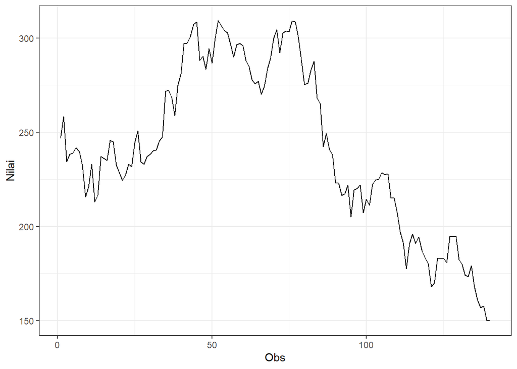

```r
dt_stas2 |> as_tsibble() |>
  ggplot(aes(x = index, y = value)) +
  geom_line() + theme_bw() +
  xlab("Obs") + ylab("Nilai")
```

Plot deret waktu di atas menunjukkan bahwa data tidak stasioner dalam rataan, ditandai dengan data yang tidak menyebar di sekitar nilai tengahnya dan tidak stasioner dalam ragam, ditandai dengan lebar pita yang cenderung tidak sama.

#### Plot ACF

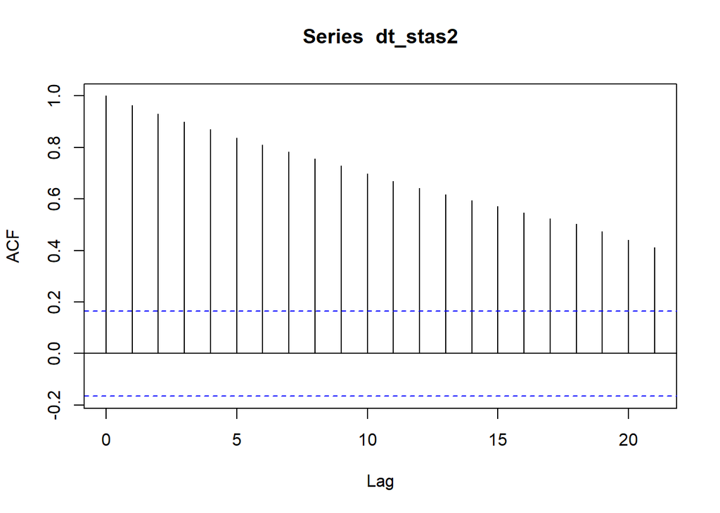

```r
acf(dt_stas2)
```

Berdasarkan plot ACF, terlihat bahwa plot ACF pada data tersebut cenderung *tails off* dan data belum stasioner ketikan grafik terlihat meluruh secara melambat menuju 0.

#### Uji ADF

```r
adf.test(dt_stas2)
```

```
##
##  Augmented Dickey-Fuller Test
##
## data:  dt_stas2
## Dickey-Fuller = -1.1423, Lag order = 5, p-value = 0.9126
## alternative hypothesis: stationary
```

$H_0$ : Data tidak stasioner dalam rataan

$H_1$ : Data stasioner dalam rataan

Berdasarkan uji ADF tersebut, didapat *p-value* sebesar 0.9126 yang lebih besar dari taraf nyata 5% sehingga tak tolak $H_0$ dan menandakan bahwa data tidak stasioner dalam rataan. Hal ini sesuai dengan hasil eksplorasi menggunakan plot time series dan plot ACF.

#### Plot Boxcox

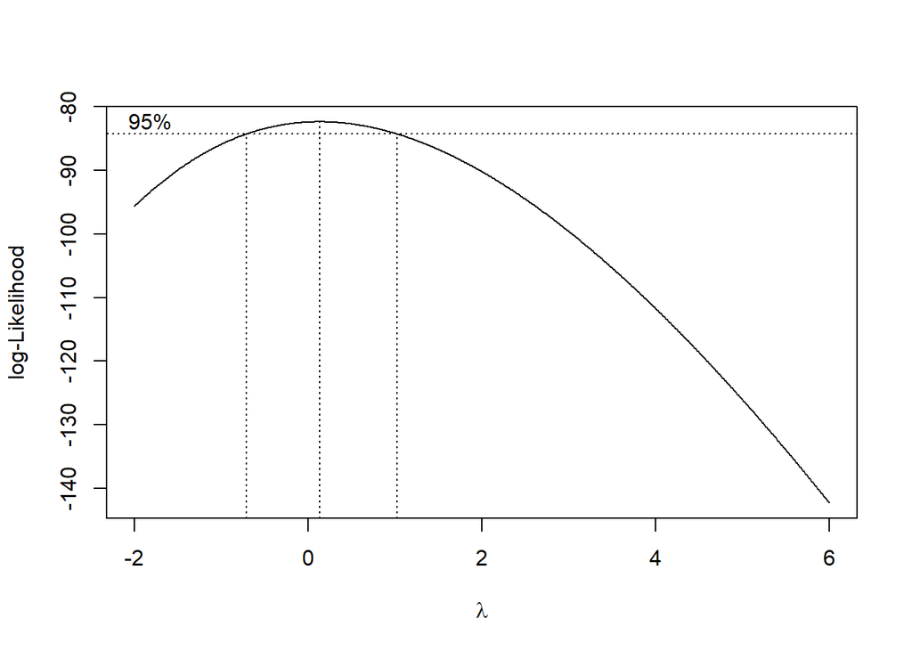

```r
index <- seq(1:140)
bc = boxcox(dt_stas2~index, lambda = seq(-2,6,by=0.01))
```

```r
#Nilai Rounded Lambda
lambda <- bc$x[which.max(bc$y)]
lambda
```

```
## [1] 0.13
```

```r
#SK
bc$x[bc$y > max(bc$y) - 1/2 * qchisq(.95,1)]
```

```
##   [1] -0.71 -0.70 -0.69 -0.68 -0.67 -0.66 -0.65 -0.64 -0.63 -0.62 -0.61 -0.60
##  [13] -0.59 -0.58 -0.57 -0.56 -0.55 -0.54 -0.53 -0.52 -0.51 -0.50 -0.49 -0.48
##  [25] -0.47 -0.46 -0.45 -0.44 -0.43 -0.42 -0.41 -0.40 -0.39 -0.38 -0.37 -0.36
##  [37] -0.35 -0.34 -0.33 -0.32 -0.31 -0.30 -0.29 -0.28 -0.27 -0.26 -0.25 -0.24
##  [49] -0.23 -0.22 -0.21 -0.20 -0.19 -0.18 -0.17 -0.16 -0.15 -0.14 -0.13 -0.12
##  [61] -0.11 -0.10 -0.09 -0.08 -0.07 -0.06 -0.05 -0.04 -0.03 -0.02 -0.01  0.00
##  [73]  0.01  0.02  0.03  0.04  0.05  0.06  0.07  0.08  0.09  0.10  0.11  0.12
##  [85]  0.13  0.14  0.15  0.16  0.17  0.18  0.19  0.20  0.21  0.22  0.23  0.24
##  [97]  0.25  0.26  0.27  0.28  0.29  0.30  0.31  0.32  0.33  0.34  0.35  0.36
## [109]  0.37  0.38  0.39  0.40  0.41  0.42  0.43  0.44  0.45  0.46  0.47  0.48
## [121]  0.49  0.50  0.51  0.52  0.53  0.54  0.55  0.56  0.57  0.58  0.59  0.60
## [133]  0.61  0.62  0.63  0.64  0.65  0.66  0.67  0.68  0.69  0.70  0.71  0.72
## [145]  0.73  0.74  0.75  0.76  0.77  0.78  0.79  0.80  0.81  0.82  0.83  0.84
## [157]  0.85  0.86  0.87  0.88  0.89  0.90  0.91  0.92  0.93  0.94  0.95  0.96
## [169]  0.97  0.98  0.99  1.00  1.01  1.02
```

Gambar di atas menunjukkan nilai *rounded value* ($\lambda$) optimum sebesar **0.13** dan pada selang kepercayaan 95% nilai memiliki batas bawah **-0.71** dan batas atas **1.02**. Selang tersebut memuat nilai satu sehingga dapat dikatakan bahwa data stasioner dalam ragam.